# Survival Analysis HW 2

Victor Feagins

9/20/2021

## 4.1 Consider the survival time of the 30 melanoma patients in Table 3.1.

```r
df.3.1 <-  read_excel("Table 3.1.xlsx")
```

```
## * Uncensor -> Uncensor...10
## * Uncensor -> Uncensor...12
```

```r
head(df.3.1, 10) %>%
  flextable() %>%
  set_caption("First 10 Observations")
```

First 10 Observations

| Patient | Age | Gender | Stage-II | Stage-III A | Stage-III B | Stage-IV A | Treatment | Remission Time | Uncensor...10 | Survival Time | Uncensor...12 |
| --- | --- | --- | --- | --- | --- | --- | --- | --- | --- | --- | --- |
| 1 | 59 | 0 | 0 | 0 | 1 | 0 | 1 | 33.7 | 0 | 33.7 | 0 |
| 2 | 50 | 0 | 0 | 0 | 1 | 0 | 1 | 3.8 | 1 | 3.9 | 1 |
| 3 | 76 | 1 | 0 | 0 | 1 | 0 | 1 | 6.3 | 1 | 10.5 | 1 |
| 4 | 66 | 0 | 0 | 0 | 1 | 0 | 1 | 2.3 | 1 | 5.4 | 1 |
| 5 | 33 | 1 | 0 | 0 | 1 | 0 | 1 | 6.4 | 1 | 19.5 | 1 |
| 6 | 23 | 0 | 0 | 0 | 1 | 0 | 1 | 23.8 | 0 | 23.8 | 0 |
| 7 | 40 | 0 | 0 | 0 | 1 | 0 | 1 | 1.8 | 1 | 7.9 | 1 |
| 8 | 34 | 1 | 0 | 0 | 1 | 0 | 1 | 5.5 | 1 | 16.9 | 0 |
| 9 | 34 | 1 | 0 | 0 | 1 | 0 | 1 | 16.6 | 0 | 16.6 | 0 |
| 10 | 38 | 0 | 1 | 0 | 0 | 0 | 1 | 33.7 | 0 | 33.7 | 0 |

### Compute and plot the PL estimates of the survivorship functions $S(t)$ of the two treatment groups and check your results with Table 3.2 and Figure 3.1.

```r
surv.model <- Surv(df.3.1$`Survival Time`, event = df.3.1$Uncensor...12)
```

```r
km <- survfit(surv.model ~ Treatment, data = df.3.1)
summary(km)
```

```
## Call: survfit(formula = surv.model ~ Treatment, data = df.3.1)
##
##                 Treatment=0
##  time n.risk n.event survival std.err lower 95% CI upper 95% CI
##   6.9     19       1    0.947  0.0512        0.852        1.000
##   7.7     18       1    0.895  0.0704        0.767        1.000
##   8.0     16       1    0.839  0.0854        0.687        1.000
##   8.3     13       1    0.774  0.1003        0.601        0.998
##  24.4      3       1    0.516  0.2211        0.223        1.000
##
##                 Treatment=1
##  time n.risk n.event survival std.err lower 95% CI upper 95% CI
##   3.9     11       1    0.909  0.0867        0.754        1.000
##   5.4     10       1    0.818  0.1163        0.619        1.000
##   7.9      9       1    0.727  0.1343        0.506        1.000
##  10.5      8       1    0.636  0.1450        0.407        0.995
##  19.5      4       1    0.477  0.1755        0.232        0.981
```

The survival times are the same with Table 3.2 in the book.

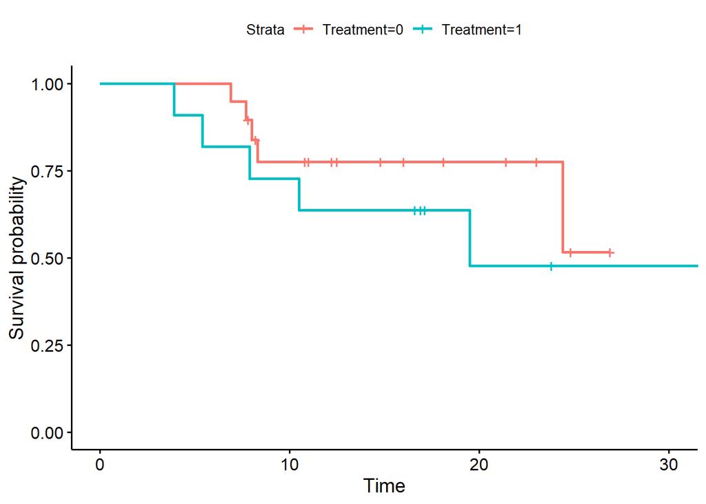

```r
ggsurvplot(km)
```

The survival curves are the same as figure 3.1 in the book.

### Compute the variance of $S(t)$ for every uncensored observation.

The following equation is used to calculate the variance of $S(t)$.

$$Var[\hat{S}(t)] = [\hat{S}(t)]^2 \sum_{r} \frac{1}{(n-r)(n-r + 1)}$$

Where $n$ is number of observations and $r$ is number of deaths.

```r
surv.data <- tidy(km)

surv.var <- surv.data %>%
  filter(n.event == 1) %>% #Looking only at uncensored observations
  group_by(strata) %>%
  mutate(S.Var = estimate^2 * cumsum(1/((max(n.risk)-cumsum(n.event))*(max(n.risk)-cumsum(n.event) + 1))))

surv.var %>%
  select(time, strata, S.Var) %>%
  flextable() %>%
  set_caption("Surival Function Variences")
```

Surival Function Variences

| time | strata | S.Var |
| --- | --- | --- |
| 6.9 | Treatment=0 | 0.002624289 |
| 7.7 | Treatment=0 | 0.004956991 |
| 8.0 | Treatment=0 | 0.006943539 |
| 8.3 | Treatment=0 | 0.008414419 |
| 24.4 | Treatment=0 | 0.005008582 |
| 3.9 | Treatment=1 | 0.007513148 |
| 5.4 | Treatment=1 | 0.013523666 |
| 7.9 | Treatment=1 | 0.018031555 |
| 10.5 | Treatment=1 | 0.021036814 |
| 19.5 | Treatment=1 | 0.017256762 |

### Estimate the median survival times of the two groups

```r
print(km)
```

```
## Call: survfit(formula = surv.model ~ Treatment, data = df.3.1)
##
##              n events median 0.95LCL 0.95UCL
## Treatment=0 19      5     NA    24.4      NA
## Treatment=1 11      5   19.5    10.5      NA
```

For treatment 0 the median is undefined since the is still more then 50% of patients alive.

## 4.4 Consider the remission data of 42 patients with acute leukemia in Example 3.3.

```
## [1] "Placebo"
```

```
##  [1]  1  1  2  2  3  4  4  5  5  8  8  8  8 11 11 12 12 15 17 22 23
```

```
## [1] "6-MP"
```

```
##  [1]  6   6   6   7  10  13  16  22  23   6+  9+ 10+ 11+ 17+ 19+ 20+ 25+ 32+ 32+
## [20] 34+ 35+
```

### Compute and plot the PL estimates of $S(t)$ at every time to relapse for the 6-MP and placebo groups.

```r
km <- survfit(surv.model.3.3 ~ treatment, data = df.3.3)
summary(km)
```

```
## Call: survfit(formula = surv.model.3.3 ~ treatment, data = df.3.3)
##
##                 treatment=6-MP
##  time n.risk n.event survival std.err lower 95% CI upper 95% CI
##     6     21       3    0.857  0.0764        0.720        1.000
##     7     17       1    0.807  0.0869        0.653        0.996
##    10     15       1    0.753  0.0963        0.586        0.968
##    13     12       1    0.690  0.1068        0.510        0.935
##    16     11       1    0.627  0.1141        0.439        0.896
##    22      7       1    0.538  0.1282        0.337        0.858
##    23      6       1    0.448  0.1346        0.249        0.807
##
##                 treatment=Placebo
##  time n.risk n.event survival std.err lower 95% CI upper 95% CI
##     1     21       2   0.9048  0.0641      0.78754        1.000
##     2     19       2   0.8095  0.0857      0.65785        0.996
##     3     17       1   0.7619  0.0929      0.59988        0.968
##     4     16       2   0.6667  0.1029      0.49268        0.902
##     5     14       2   0.5714  0.1080      0.39455        0.828
##     8     12       4   0.3810  0.1060      0.22085        0.657
##    11      8       2   0.2857  0.0986      0.14529        0.562
##    12      6       2   0.1905  0.0857      0.07887        0.460
##    15      4       1   0.1429  0.0764      0.05011        0.407
##    17      3       1   0.0952  0.0641      0.02549        0.356
##    22      2       1   0.0476  0.0465      0.00703        0.322
##    23      1       1   0.0000     NaN           NA           NA
```

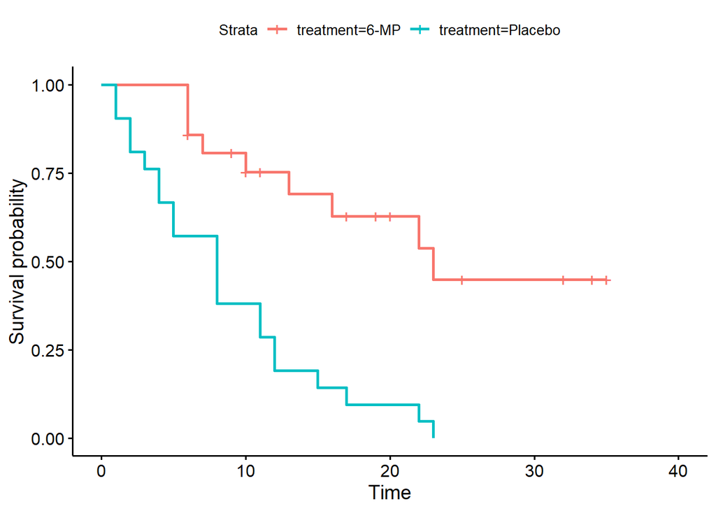

```r
ggsurvplot(km)
```

### Compute the variances of $S(10)$ in the 6-MP group and of $S(3)$ in the placebo group.

```r
surv.data <- tidy(km)

surv.var <- surv.data %>%
  filter(n.event == 1) %>% #Looking only at uncensored observations
  group_by(strata) %>%
  mutate(S.Var = estimate^2 * cumsum(1/((max(n.risk)-cumsum(n.event))*(max(n.risk)-cumsum(n.event) + 1))))

surv.var %>%
  select(time, strata, S.Var) %>%
  filter(time == 10 | time == 3) %>%
  flextable() %>%
  set_caption("Surival Function Variences S(10) & S(3)")
```

Surival Function Variences S(10) & S(3)

| time | strata | S.Var |
| --- | --- | --- |
| 10 | treatment=6-MP | 0.004446435 |
| 3 | treatment=Placebo | 0.002134187 |

### Estimate the median remission times of the two treatment groups.

```r
print(km)
```

```
## Call: survfit(formula = surv.model.3.3 ~ treatment, data = df.3.3)
##
##                    n events median 0.95LCL 0.95UCL
## treatment=6-MP    21      9     23      16      NA
## treatment=Placebo 21     21      8       4      12
```

## 4.9 Do a complete life-table analysis of the data given in Exercise Table 4.2, the Angina Pectoris data.

```r
df.4.9 <- read_excel("Female4.2.xlsx")
head(df.4.9) %>%
  flextable() %>%
  set_caption("First 5 Observations")
```

| Interval | Number_At_Risk | Censored | Deaths |
| --- | --- | --- | --- |
| 0—1 | 555 | 0 | 82 |
| 1—2 | 473 | 8 | 30 |
| 2—3 | 435 | 8 | 27 |
| 3—4 | 400 | 7 | 22 |
| 4—5 | 371 | 7 | 26 |
| 5—6 | 338 | 28 | 25 |

This data is different format of survival data. R handles survival data where each row is an event. So we will need to transform the data by replicated the number of rows by the associated rows frequency

```r
df.4.9.t <- rbind(data.d, data.c)
df.4.9.t <- df.4.9.t %>%
  tidyr::separate(Interval, c("Start", "End"), "—") %>%
  mutate(Deaths = ifelse(is.na(End), 0, Deaths),# if we don't know when they died make it censored
         End = ifelse(is.na(End), 15, End))
```

Once that transformation is done survival analysis is the same steps as the previous problems.

```r
surv.model.4.9 <- Surv(#time = as.numeric(df.4.9.t$Start),
                       time = as.numeric(df.4.9.t$End),
                       event = df.4.9.t$Deaths)
```

```r
km <- survfit(surv.model.4.9 ~ 1, data = df.4.9.t)
summary(km)
```

```
## Call: survfit(formula = surv.model.4.9 ~ 1, data = df.4.9.t)
##
##  time n.risk n.event survival std.err lower 95% CI upper 95% CI
##     1    555      82    0.852  0.0151        0.823        0.882
##     2    473      30    0.798  0.0170        0.765        0.832
##     3    435      27    0.749  0.0185        0.713        0.786
##     4    400      22    0.707  0.0194        0.670        0.747
##     5    371      26    0.658  0.0203        0.619        0.699
##     6    338      25    0.609  0.0210        0.569        0.652
##     7    285      20    0.566  0.0216        0.526        0.610
##     8    234      11    0.540  0.0220        0.498        0.585
##     9    191      14    0.500  0.0228        0.457        0.547
##    10    153      13    0.458  0.0237        0.414        0.507
##    11    113       5    0.438  0.0244        0.392        0.488
##    12     86       5    0.412  0.0255        0.365        0.465
##    13     58       5    0.377  0.0278        0.326        0.435
##    14     35       2    0.355  0.0301        0.301        0.419
##    15     24       3    0.311  0.0356        0.248        0.389
```

### Plot the three survival functions: survival, hazard and density functions.

#### Survival Function

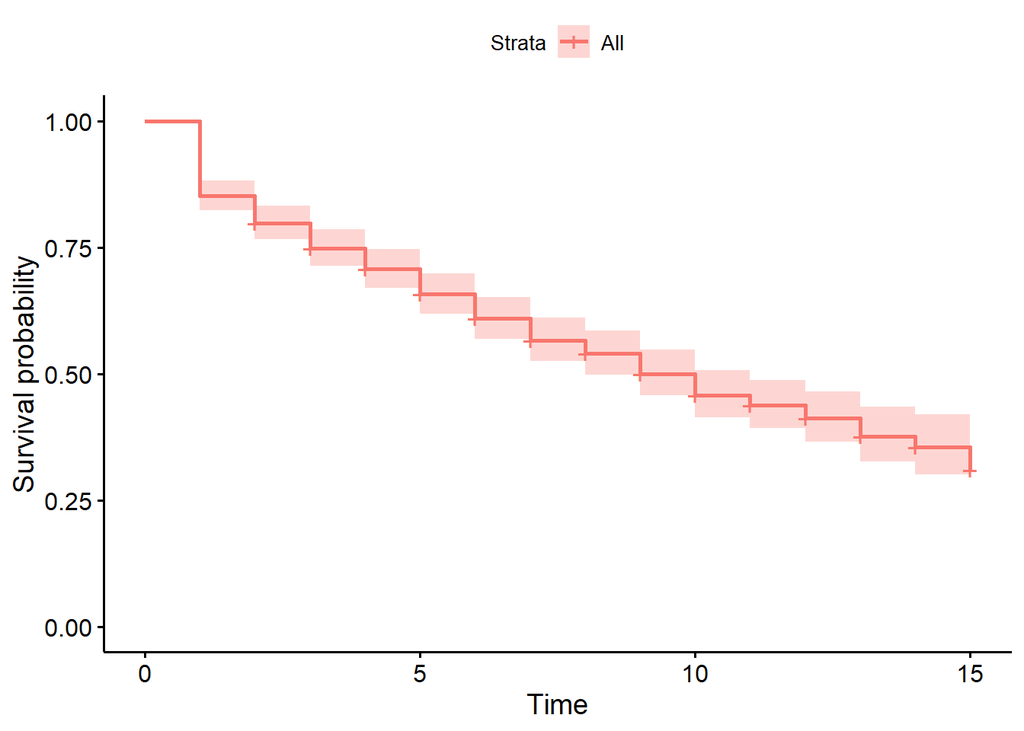

```r
ggsurvplot(km)
```

#### Hazard Function

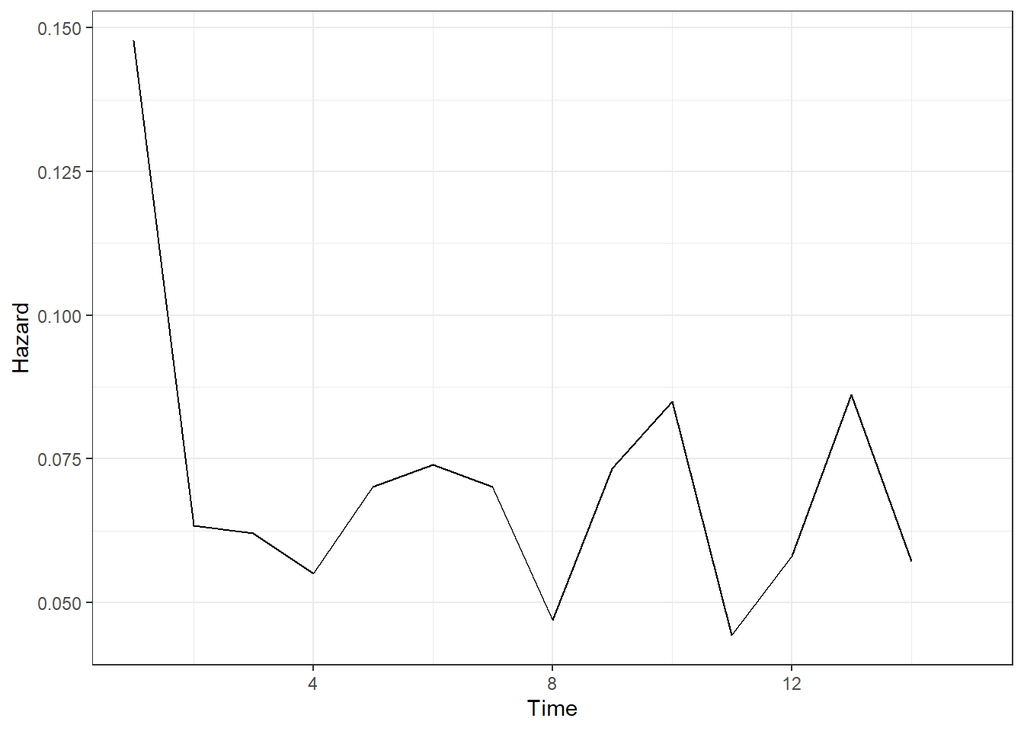

```r
survival.table1 <- broom::tidy(km) %>% filter(n.event > 0)
survival.table1 <- survival.table1 %>% mutate(hazard = n.event / (n.risk * (lead(time) - time)))
ggplot() +
  geom_line(data = survival.table1, aes(x = time, y = hazard)) +
  labs(x = "Time", y = "Hazard")
```

### Probablity

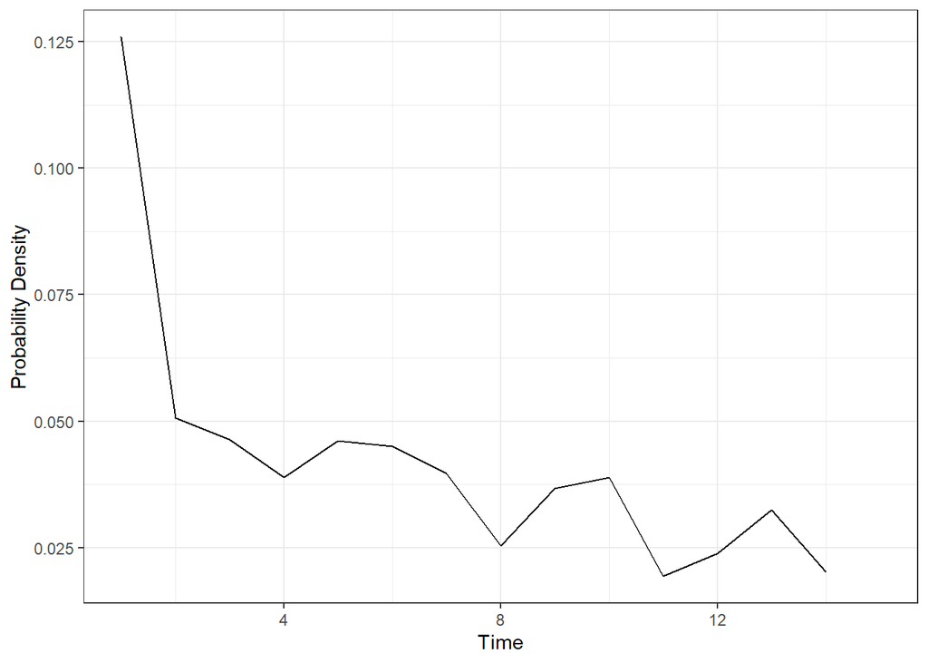

```r
survival.table1 <- survival.table1 %>% mutate(probability  = estimate * hazard)
ggplot() +
  geom_line(data = survival.table1, aes(x = time, y = probability)) +
  labs(x = "Time", y = "Probability Density")
```